# 13_2_sql_accepted

**Hello, Jolene!👋 How are you today?** My name is Arina U. and I am glad to be your reviewer in this project! Nice to meet you! 💪😎  
You can find my comments in green, yellow and red boxes. Examples you can see below:

## Reviewer's commentary

**Well done!👍:** In case if task is completely correct and everything is alright!

## Reviewer's commentary

**Remarks and recommendations📌:** In case when I can give some advice that can help you to improve your work or recommend you some useful links and resources that can help you widen your knowledge and help in future tasks.

## Reviewer's commentary

**Needs fixing!🤔:** In case when step requires some extra work and some corrections. Project can't be accepted with comments in the red boxes

Please pay attention to not move or change my comments. It would be good to highlight your answers in some way.

#### Student's commentary: for example like this

OK, now let's go!😏 </font>

#### Student's commentary: for example like this

Hi Arina, Thank you for reviewing my project. I want to be a good coder, so I appreciate your feedback. I have made updates below.

## Reviewer's commentary:second iteration of the review

**Well done!👍:** Hello again, Jolene! Thank you so much for your feedback, I am happy to know that the review was useful!💪

# Final Project: SQL

*Project Background*

- The coronavirus took the entire world by surprise, changing everyone's daily routine. City dwellers no longer spent their free time outside, going to cafes and malls; more people were at home, reading books. That attracted the attention of startups that rushed to develop new apps for book lovers.
- You've been given a database of one of the services competing in this market. It contains data on books, publishers, authors, and customer ratings and reviews of books. This information will be used to generate a value proposition for a new product.
- Value Propositions:
  - A company's value proposition tells a customer the number one reason why a product or service is best suited for that particular customer.
  - A value proposition should be communicated to customers directly, either via the company's website or other marketing or advertising materials.
  - Value propositions can follow different formats, as long as they are "on brand," unique, and specific to the company in question.
  - A successful value proposition should be persuasive and help turn a prospect into a paying customer.
  - More info: https://www.investopedia.com/terms/v/valueproposition.asp

*Project Goal*

- Use the provided databases on books, publishers, authors, and customer ratings and reviews of books to collect information that will be used to generate a value proposition for a new product.

*Instructions for completing the project*

- Describe the goals of the study.
- Study the tables (print the first rows).
  - `books` Table
  - `authors` Table
  - `publishers` Table
  - `ratings` Table
  - `reviews` Table
- Make a SQL query for each of the tasks.
  - Find the number of books released after January 1, 2000.
  - Find the number of user reviews and the average rating for each book.
  - Identify the publisher that has released the greatest number of books with more than 50 pages (this will help you exclude brochures and similar publications from your analysis).
  - Identify the author with the highest average book rating (look only at books with at least 50 ratings).
  - Find the average number of text reviews among users who rated more than 50 books.
- Output the results of each query in the Notebook.
- Describe your conclusions for each of the tasks.

*Important things to consider*

- Don't forget functions! They can make your life and running queries considerably easier.
- Your results must be obtained with SQL. Use pandas only to print and store query results.

*Description of the data*

- `**books**` - Contains data on books:
  - `book_id`
  - `author_id`
  - `title`
  - `num_pages` — number of pages
  - `publication_date`
  - `publisher_id`
- `**authors**` - Contains data on authors:
  - `author_id`
  - `author`
- `**publishers**` - Contains data on publishers:
  - `publisher_id`
  - `publisher`
- `**ratings**` - Contains data on user ratings:
  - `rating_id`
  - `book_id`
  - `username` — the name of the user who rated the book
  - `rating`
- `**reviews**` - Contains data on customer reviews:
  - `review_id`
  - `book_id`
  - `username` — the name of the user who reviewed the book
  - `text` — the text of the review

## Reviewer's commentary

**Well done!👍:** Ok, good intro to the project!

# Import Libraries

```python
import pandas as pd
from sqlalchemy import create_engine
```

# Connect to the database

```python
# Create a data base connection
db_config = {'user': 'praktikum_student',         # user name
             'pwd': 'Sdf4$2;d-d30pp', # password
             'host': 'rc1b-wcoijxj3yxfsf3fs.mdb.yandexcloud.net',
             'port': 6432,              # connection port
             'db': 'data-analyst-final-project-db'}          # the name of the data base

connection_string = 'postgresql://{}:{}@{}:{}/{}'.format(db_config['user'],
                                                                     db_config['pwd'],
                                                                       db_config['host'],
                                                                       db_config['port'],
                                                                       db_config['db'])

engine = create_engine(connection_string, connect_args={'sslmode':'require'})
```

# Study the tables (print the first rows)

- `books` Table
- `authors` Table
- `publishers` Table
- `ratings` Table
- `reviews` Table

```python
# create a fucntion that runs queries and prints first few rows
def sql_query_print_five(database_table):
    query = '''SELECT * FROM {}'''.format(database_table)
    results = pd.io.sql.read_sql(query, con = engine)
    return results.head()
```

*`books` Table*

```python
books_table = sql_query_print_five('books')
books_table
```

|  | book_id | author_id | title | num_pages | publication_date | publisher_id |
| --- | --- | --- | --- | --- | --- | --- |
| 0 | 1 | 546 | 'Salem's Lot | 594 | 2005-11-01 | 93 |
| 1 | 2 | 465 | 1 000 Places to See Before You Die | 992 | 2003-05-22 | 336 |
| 2 | 3 | 407 | 13 Little Blue Envelopes (Little Blue Envelope... | 322 | 2010-12-21 | 135 |
| 3 | 4 | 82 | 1491: New Revelations of the Americas Before C... | 541 | 2006-10-10 | 309 |
| 4 | 5 | 125 | 1776 | 386 | 2006-07-04 | 268 |

*`authors` Table*

```python
authors_table = sql_query_print_five('authors')
authors_table
```

|  | author_id | author |
| --- | --- | --- |
| 0 | 1 | A.S. Byatt |
| 1 | 2 | Aesop/Laura Harris/Laura Gibbs |
| 2 | 3 | Agatha Christie |
| 3 | 4 | Alan Brennert |
| 4 | 5 | Alan Moore/David Lloyd |

*`publishers` Table*

```python
publishers_table = sql_query_print_five('publishers')
publishers_table
```

|  | publisher_id | publisher |
| --- | --- | --- |
| 0 | 1 | Ace |
| 1 | 2 | Ace Book |
| 2 | 3 | Ace Books |
| 3 | 4 | Ace Hardcover |
| 4 | 5 | Addison Wesley Publishing Company |

*`ratings` Table*

```python
ratings_table = sql_query_print_five('ratings')
ratings_table
```

|  | rating_id | book_id | username | rating |
| --- | --- | --- | --- | --- |
| 0 | 1 | 1 | ryanfranco | 4 |
| 1 | 2 | 1 | grantpatricia | 2 |
| 2 | 3 | 1 | brandtandrea | 5 |
| 3 | 4 | 2 | lorichen | 3 |
| 4 | 5 | 2 | mariokeller | 2 |

*`reviews` Table*

```python
reviews_table = sql_query_print_five('reviews')
reviews_table
```

|  | review_id | book_id | username | text |
| --- | --- | --- | --- | --- |
| 0 | 1 | 1 | brandtandrea | Mention society tell send professor analysis. ... |
| 1 | 2 | 1 | ryanfranco | Foot glass pretty audience hit themselves. Amo... |
| 2 | 3 | 2 | lorichen | Listen treat keep worry. Miss husband tax but ... |
| 3 | 4 | 3 | johnsonamanda | Finally month interesting blue could nature cu... |
| 4 | 5 | 3 | scotttamara | Nation purpose heavy give wait song will. List... |

- A function was used to evaluate the first five rows of each table

## Reviewer's commentary

**Well done!👍:** Ok, you managed to investigate the data, let's move on!

# Make a SQL query for each of the tasks.

- Find the number of books released after January 1, 2000.
- Find the number of user reviews and the average rating for each book.
- Identify the publisher that has released the greatest number of books with more than 50 pages (this will help you exclude brochures and similar publications from your analysis).
- Identify the author with the highest average book rating (look only at books with at least 50 ratings).
- Find the average number of text reviews among users who rated more than 50 books.

```python
# create a function to read and provide the results of each query
def read_results(query_name):
    results = pd.io.sql.read_sql(query_name, con = engine)
    return results
```

*Find the number of books released after January 1, 2000.*

```python
num_books_query = '''
SELECT
    COUNT(*) AS num_books_released
FROM
    books
WHERE
    publication_date > '2000-01-01';
'''
num_books_query_result = read_results(num_books_query)
num_books_query_result
```

|  | num_books_released |
| --- | --- |
| 0 | 819 |

- In this dataset there are 819 books released after January 1, 2000

## Reviewer's commentary

**Well done!👍:** Ok, agree with your result here!

*Find the number of user reviews and the average rating for each book*

```python
num_reviews_avg_rating_query = '''
SELECT
    books.book_id,
    books.title,
    COUNT(reviews.review_id) AS num_user_reviews,
    ROUND(AVG(ratings.rating), 2) AS avg_rating_per_book
FROM
    books
    LEFT JOIN reviews ON books.book_id = reviews.book_id
    LEFT JOIN ratings ON books.book_id = ratings.book_id
GROUP BY
    books.book_id
ORDER BY
    num_user_reviews DESC;
'''
num_reviews_avg_rating_results = read_results(num_reviews_avg_rating_query)
num_reviews_avg_rating_results
```

|  | book_id | title | num_user_reviews | avg_rating_per_book |
| --- | --- | --- | --- | --- |
| 0 | 948 | Twilight (Twilight #1) | 1120 | 3.66 |
| 1 | 750 | The Hobbit or There and Back Again | 528 | 4.13 |
| 2 | 673 | The Catcher in the Rye | 516 | 3.83 |
| 3 | 302 | Harry Potter and the Prisoner of Azkaban (Harr... | 492 | 4.41 |
| 4 | 299 | Harry Potter and the Chamber of Secrets (Harry... | 480 | 4.29 |
| ... | ... | ... | ... | ... |
| 995 | 221 | Essential Tales and Poems | 0 | 4.00 |
| 996 | 808 | The Natural Way to Draw | 0 | 3.00 |
| 997 | 191 | Disney's Beauty and the Beast (A Little Golden... | 0 | 4.00 |
| 998 | 83 | Anne Rice's The Vampire Lestat: A Graphic Novel | 0 | 3.67 |
| 999 | 672 | The Cat in the Hat and Other Dr. Seuss Favorites | 0 | 5.00 |

1000 rows × 4 columns

- Several tables were combined to create a table showing the number of reviews and the averge rating for each book

## Reviewer's commentary

**Needs fixing!🤔:**

Your result is not very correct here.

It is better not to use the DISTINCT with COUNT we get not all the reviews for each book? also, it is better to sort the table in descending order by the number of the reviews to get the leaders at the top of the table, look at the example:

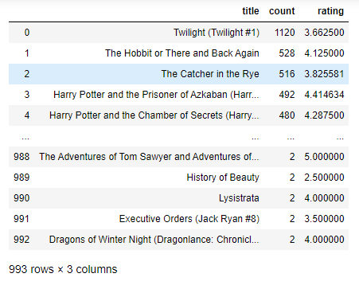

#### Student's commentary: for example like this

I removed DISTINCT and put the table in descending order.

I see now that I completely glanced over the results and didnt think about it thoroughly enough before moving on. I will aim to be better in the future.

## Reviewer's commentary:second iteration of the review

**Well done!👍:**

Ok, this time the result is correct! Yes, the idea here, that we want to know the number of all reviews per each book, also ordering can be important thing, it's matter by what column we sort and in what order.

*Identify the publisher that has released the greatest number of books with more than 50 pages (this will help you exclude brochures and similar publications from your analysis).*

```python
publishers_with_most_query = '''
SELECT publishers.publisher,
    COUNT(DISTINCT(books.book_id)) AS num_books_published
FROM publishers
    INNER JOIN books ON books.publisher_id = publishers.publisher_id
WHERE
    books.num_pages > 50
GROUP BY
    publisher
ORDER BY
    num_books_published DESC
LIMIT 1;
'''
publishers_with_most_query_results = read_results(publishers_with_most_query)
publishers_with_most_query_results.head()
```

|  | publisher | num_books_published |
| --- | --- | --- |
| 0 | Penguin Books | 42 |

- Some tables were combined to discover that Penguin Books has published the most books with 42 books published, this was determined by excluding any books that had less than 50 pages.

## Reviewer's commentary

**Remarks and recommendations📌:** As a whole correct, but try to use LIMIT here to get the leader👀

#### Student's commentary: for example like this

I focused on the top result. </font>

## Reviewer's commentary:second iteration of the review

**Well done!👍:**

Ok, good!

*Identify the author with the highest average book rating (look only at books with at least 50 ratings).*

```python
highest_avg_book_query = '''
SELECT
    title,
    author,
    AVG(rating) AS average_book_rating
FROM
    (SELECT
    *
    FROM
        books
        INNER JOIN authors on authors.author_id = books.author_id
        INNER JOIN ratings on ratings.book_id = books.book_id) AS book_data
GROUP BY
    author,
    title
HAVING COUNT(rating) > 50
ORDER BY average_book_rating DESC
LIMIT 1;
'''
highest_avg_book_query_results = pd.io.sql.read_sql(highest_avg_book_query, con = engine)
highest_avg_book_query_results.head()
```

|  | title | author | average_book_rating |
| --- | --- | --- | --- |
| 0 | Harry Potter and the Prisoner of Azkaban (Harr... | J.K. Rowling/Mary GrandPré | 4.414634 |

- Several tables were combined to discover that the authors J.K. Rowling/Mary GrandPre have the highest average book rating out of books with at least 50 ratings.

## Reviewer's commentary

**Remarks and recommendations📌:**

Ok, good job, but still we need to look at the leader.

#### Student's commentary: for example like this

I focused on the top result. </font>

## Reviewer's commentary:second iteration of the review

**Well done!👍:**

Ok, correct now!

*Find the average number of text reviews among users who rated more than 50 books*

```python
avg_user_reviews_query = '''
WITH users_with_fifty_reviews (username) AS (
    SELECT
        ratings.username
    FROM
        ratings
    GROUP BY
        username
    HAVING COUNT(rating_id) > 50
    ),
    user_review_data AS (
        SELECT
            DISTINCT username,
            COUNT(review_id) OVER (partition by username) AS reviews_count
        FROM users_with_fifty_reviews
            INNER JOIN reviews USING(username)
    )
SELECT
    ROUND(AVG(reviews_count), 2) AS avg_user_reviews
FROM
    user_review_data
'''
avg_user_reviews_query_results = pd.io.sql.read_sql(avg_user_reviews_query, con = engine)
avg_user_reviews_query_results.head()
```

|  | avg_user_reviews |
| --- | --- |
| 0 | 24.33 |

## Reviewer's commentary

**Well done!👍** Nothing to add, the result is correct, good job!

# Project Conclusion

- Based on the data queries being requested it looks like the value proposition being formulated will involve book ratings with a possible focus on popular books, publishers, and authors

**The overall review conclusion**

Jolene, thank you for submitting your project! I can see that you've worked really hard on it! I'm really impressed this the amount of work you have done. But there are several things in your project which I suppose it is important to fix, my comments will navigate you.

**Good things and practices in your project I want to highlight🙂**:

- You used different methods for working with your data. It is really great that you can apply these methods on practice, keep it up!
- It is great that you formulated conclusions and explanations after each step of the analysis.

**What is worth working on👀**:

- all the recommendations you can find in my comments, please, try to work on them, some queries need to be improved.

**Good luck! I will wait for your work for a second iteration of the review!😉**

[figure not shown]

**The overall review conclusion: second iteration of the review**

Jolene, thank you for submitting your project with corrections!😉

You did a great job to improve the project, I can see your progress, so I hasten to say that your project has been accepted and you can proceed to the next sprint!

**I wish you exciting and cool projects in the next sprints😉**

[figure not shown]